# STAT 240: dplyr Practice Solutions

# Read in Data

```r
## read in the data
official = read_csv("../../data/madison-weather-official-1869-2022.csv")
```

# Annual Average Temperature

> Create a summary table of the data with the average temperature per year. Then, make an effective plot of this data to show patterns over time and variation around the main pattern.

```r
mw1 = official %>%
  ## drop any rows with missing data in tavg
  drop_na(tavg) %>%
  ## use the lubridate function year() to extract the year from the date
  mutate(year = year(date)) %>%
  ## group by year
  group_by(year) %>%
  ## calculate the average temperature by each year
  summarize(yearlyTemp = mean(tavg))

mw1
```

```
## # A tibble: 154 × 2
##     year yearlyTemp
##    <dbl>      <dbl>
##  1  1869       43.4
##  2  1870       47.8
##  3  1871       46.3
##  4  1872       44.0
##  5  1873       44.0
##  6  1874       46.5
##  7  1875       42.5
##  8  1876       45.4
##  9  1877       47.8
## 10  1878       49.8
## # ℹ 144 more rows
```

[figure not shown]

```r
ggplot(mw1, aes(x = year, y = yearlyTemp)) +
  geom_point() +
  geom_line() +
  geom_smooth(se = FALSE) +
  labs(
    x = "Year",
    y = "Temperature (F)",
    title = "Madison Average Annual Temperature Over Time",
    subtitle = "1869-2021"
  )
```

# Daily Temperature Records

```r
official %>%
  mutate(year = year(date),
         month = month(date, label = TRUE),
         day = day(date)) %>%
  group_by(month, day) %>%
  slice_max(tavg, n = 1)
```

```
## # A tibble: 404 × 11
## # Groups:   month, day [366]
##    name    date        prcp  snow snow_depth  tmin  tmax  tavg  year month   day
##    <chr>   <date>     <dbl> <dbl>      <dbl> <dbl> <dbl> <dbl> <dbl> <ord> <int>
##  1 Bureau  1897-01-01  0.32     0       NA      42    54  48    1897 Jan       1
##  2 Airport 1950-01-02  0.29     0        0      39    48  43.5  1950 Jan       2
##  3 Bureau  1874-01-03  0       NA       NA      39    57  48    1874 Jan       3
##  4 Bureau  1880-01-04  0.5     NA       NA      36    53  44.5  1880 Jan       4
##  5 Airport 1946-01-05  0.49     0        0      39    50  44.5  1946 Jan       5
##  6 Bureau  1880-01-06  0.06    NA       NA      39    58  48.5  1880 Jan       6
##  7 Airport 1965-01-07  0.02     0        0      39    45  42    1965 Jan       7
##  8 Airport 2008-01-07  0.59     0        3      34    50  42    2008 Jan       7
##  9 Airport 2019-01-07  1.1      0        1.2    36    48  42    2019 Jan       7
## 10 Bureau  1880-01-08  0.06    NA       NA      39    50  44.5  1880 Jan       8
## # ℹ 394 more rows
```

# Temperature by 30-year period

> Meteorologists often determine weather norms by averaging over a 30-year period. Create a variable which partitions the data into 30-year periods from 1871-1900, 1901-1930, up to 1991-2020. You can exclude years before 1871 and after 2020.

> Then calculate within each of the twelve months within each period (e.g. 1 row for all Januarys in 1871-1900, 1 row for all Februarys in 1871-1900…) the average, maximum, and minimum of the average temperature.

```r
# Create variables and filter
prob2 = official %>%
  mutate(year = year(date),
         month = month(date, label = TRUE)) %>%
  filter(year > 1870 & year < 2021) %>%
  mutate(period30 = case_when(
    year > 1870 & year <= 1900 ~ "1871-1900",
    year > 1900 & year <= 1930 ~ "1901-1930",
    year > 1930 & year <= 1960 ~ "1931-1960",
    year > 1960 & year <= 1990 ~ "1961-1990",
    year > 1990 & year <= 2020 ~ "1991-2020"))

prob2 %>% count(period30) # appears to have worked correctly
```

```
## # A tibble: 5 × 2
##   period30      n
##   <chr>     <int>
## 1 1871-1900 10957
## 2 1901-1930 10957
## 3 1931-1960 10958
## 4 1961-1990 10957
## 5 1991-2020 10958
```

```r
# Summarize to the month-period level
prob2_summarized = prob2 %>%
  # Drop those 14 dates with missing tavg
  drop_na(tavg) %>%
  group_by(month, period30) %>%
  summarize(minimum = min(tavg), maximum = max(tavg), average = mean(tavg))

prob2_summarized
```

```
## # A tibble: 60 × 5
## # Groups:   month [12]
##    month period30  minimum maximum average
##    <ord> <chr>       <dbl>   <dbl>   <dbl>
##  1 Jan   1871-1900   -20.5    48.5    16.2
##  2 Jan   1901-1930   -19.5    46.5    16.9
##  3 Jan   1931-1960   -19      53      20.1
##  4 Jan   1961-1990   -18.5    45.5    16.0
##  5 Jan   1991-2020   -20      45.5    19.5
##  6 Feb   1871-1900   -21.5    54      19.6
##  7 Feb   1901-1930   -15.5    52.5    19.7
##  8 Feb   1931-1960   -15      48      22.1
##  9 Feb   1961-1990   -11.5    49.5    20.6
## 10 Feb   1991-2020   -19.5    53      23.2
## # ℹ 50 more rows
```

# Days With Precipitation

> Make a summary table which shows the proportion of days which had any precipitation in each 30-year period + month combination.

```r
# prob2 is the same as official, at the date level, with period30 and month already created

prob4 = prob2 %>%
  drop_na(prcp) %>%
  group_by(month, period30) %>%
  summarize(any_prcp = sum(prcp > 0),
            all_days = n(),
            percentPrcp = any_prcp/n())

prob4
```

```
## # A tibble: 60 × 5
## # Groups:   month [12]
##    month period30  any_prcp all_days percentPrcp
##    <ord> <chr>        <int>    <int>       <dbl>
##  1 Jan   1871-1900      248      930       0.267
##  2 Jan   1901-1930      259      930       0.278
##  3 Jan   1931-1960      287      930       0.309
##  4 Jan   1961-1990      314      930       0.338
##  5 Jan   1991-2020      318      930       0.342
##  6 Feb   1871-1900      222      847       0.262
##  7 Feb   1901-1930      217      846       0.257
##  8 Feb   1931-1960      254      848       0.300
##  9 Feb   1961-1990      235      847       0.277
## 10 Feb   1991-2020      289      848       0.341
## # ℹ 50 more rows
```

> With a separate panel for each month, create a column graph of the percentage of precipitation in each 30-year period.

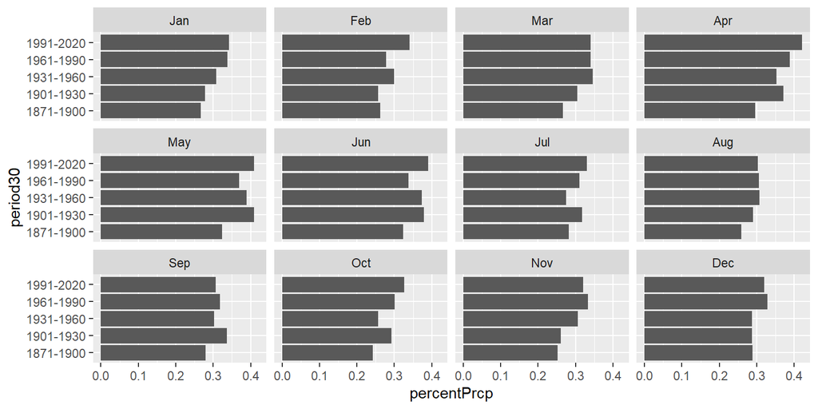

```r
ggplot(prob4, aes(percentPrcp, period30)) +
  geom_col() +
  facet_wrap(~month)
```